# Titanic

#### Famous Salami, salamifamous@gmail.com

#### Titanic Dataset: Exploratory Data Analysis and Visualization

```python
import pandas as pd
import  matplotlib.pyplot as plt
import seaborn as sns
import numpy as np
import re
colors = ['#36454F', '#DC143C', '#fdaa48','#6890F0','#A890F0']
```

## Exploratory Data Analysis

```python
data = pd.read_csv("Titanic Dataset.csv")
raw_data = pd.read_csv("Titanic Dataset.csv")
data.head(6)
```

|  | PassengerId | Survived | Pclass | Name | Sex | Age | SibSp | Parch | Ticket | Fare | Cabin | Embarked |
| --- | --- | --- | --- | --- | --- | --- | --- | --- | --- | --- | --- | --- |
| 0 | 1 | 0 | 3 | Braund, Mr. Owen Harris | male | 22.0 | 1 | 0 | A/5 21171 | 7.2500 | NaN | S |
| 1 | 2 | 1 | 1 | Cumings, Mrs. John Bradley (Florence Briggs Th... | female | 38.0 | 1 | 0 | PC 17599 | 71.2833 | C85 | C |
| 2 | 3 | 1 | 3 | Heikkinen, Miss. Laina | female | 26.0 | 0 | 0 | STON/O2. 3101282 | 7.9250 | NaN | S |
| 3 | 4 | 1 | 1 | Futrelle, Mrs. Jacques Heath (Lily May Peel) | female | 35.0 | 1 | 0 | 113803 | 53.1000 | C123 | S |
| 4 | 5 | 0 | 3 | Allen, Mr. William Henry | male | 35.0 | 0 | 0 | 373450 | 8.0500 | NaN | S |
| 5 | 6 | 0 | 3 | Moran, Mr. James | male | NaN | 0 | 0 | 330877 | 8.4583 | NaN | Q |

```python
data.info()
```

```
<class 'pandas.core.frame.DataFrame'>
RangeIndex: 891 entries, 0 to 890
Data columns (total 12 columns):
 #   Column       Non-Null Count  Dtype
---  ------       --------------  -----
 0   PassengerId  891 non-null    int64
 1   Survived     891 non-null    int64
 2   Pclass       891 non-null    int64
 3   Name         891 non-null    object
 4   Sex          891 non-null    object
 5   Age          714 non-null    float64
 6   SibSp        891 non-null    int64
 7   Parch        891 non-null    int64
 8   Ticket       891 non-null    object
 9   Fare         891 non-null    float64
 10  Cabin        204 non-null    object
 11  Embarked     889 non-null    object
dtypes: float64(2), int64(5), object(5)
memory usage: 83.7+ KB
```

```python
data.isna().sum()
```

```
PassengerId      0
Survived         0
Pclass           0
Name             0
Sex              0
Age            177
SibSp            0
Parch            0
Ticket           0
Fare             0
Cabin          687
Embarked         2
dtype: int64
```

```python
survivor_group = data['Survived'].value_counts()
print(survivor_group)
print()
prcnt_surv = (survivor_group[1] / data.shape[0]) * 100
prcnt_n_surv = (survivor_group[0] / data.shape[0]) * 100

print(f'Percentage of survivors is {round(prcnt_surv)}%')
print(f'Percentage of non-survivors is {round(prcnt_n_surv)}%')
```

```
Survived
0    549
1    342
Name: count, dtype: int64

Percentage of survivors is 38%
Percentage of non-survivors is 62%
```

### Observations

- The dataset shows information about the passengers on board the Titanic ship. It comprises of 891 observations (rows)  
  and features (columns), representing passengers.
- There are missing values in three major entries, which are 'Age', 'Cabin' and 'Port of Embarkation'; the missing values are listed below:  
  'Cabin' has 687 missing values  
  'Age' has 177 missing values  
  'Embarkation' has 2 missing values
- The dataset records a total of 342 survivors, representing 38% of the entire passengers, while 549, 62% died in the shipwreck.

## Data Cleaning and Preprocessing

```python
# Embarkation Port has 2 missing data, this would be filled using the forward fill method
data['Embarked'] = data['Embarked'].ffill()
missing_embarkation_rows = data['Embarked'].isna().sum()
print(f'Missing embarkation port after cleaning is: {missing_embarkation_rows}')
```

```
Missing embarkation port after cleaning is: 0
```

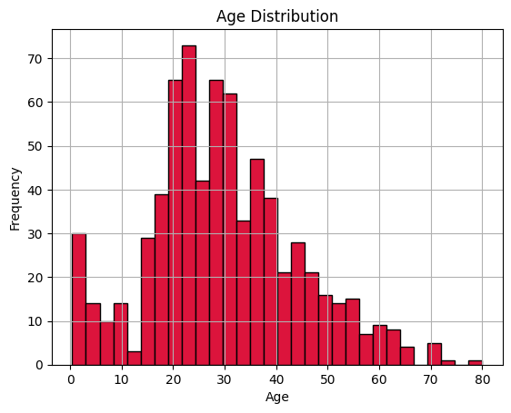

```python
data['Age'].hist(bins=30, color=colors[1], edgecolor='black')

plt.title('Age Distribution')
plt.xlabel('Age')
plt.ylabel('Frequency')
plt.show()
```

- The histogram plot of the Age distribution is right-skewed, this implies the median is the most accurate value to use in filling the missing age
- I would use a more suitable approach to address missing age values by first extracting passenger titles. Then, I'll fill the missing age values with the median age corresponding to each title group.

```python
title_conditions = [
    data['Name'].str.contains(r'\bMr\b', case=False, regex=True),
    data['Name'].str.contains(r'\bMrs\b', case=False, regex=True),
    data['Name'].str.contains(r'\bMiss\b', case=False, regex=True)
]

titles = ['Mr', 'Mrs', 'Miss']
data['Title'] = np.select(title_conditions, titles, default='NA') # Engineering a new feature, `Title`
```

```python
# Age has 177 missing data, these would be filled with the median age of each title group
median_age_by_title = data.groupby('Title')['Age'].median()

data['Age'] = data.apply(lambda row: median_age_by_title[row['Title']] if pd.isnull(row['Age']) else row['Age'], axis=1)

missing_age_data = data['Age'].isna().sum()
print(f'Missing age entries after cleaning is: {missing_age_data}')
```

```
Missing age entries after cleaning is: 0
```

```python
# The Cabin feature has too many missing data, representing 77% of the dataset, it is therefore better dropped [in this context]
data = data.drop(columns='Cabin')
data.info()
```

```
<class 'pandas.core.frame.DataFrame'>
RangeIndex: 891 entries, 0 to 890
Data columns (total 12 columns):
 #   Column       Non-Null Count  Dtype
---  ------       --------------  -----
 0   PassengerId  891 non-null    int64
 1   Survived     891 non-null    int64
 2   Pclass       891 non-null    int64
 3   Name         891 non-null    object
 4   Sex          891 non-null    object
 5   Age          891 non-null    float64
 6   SibSp        891 non-null    int64
 7   Parch        891 non-null    int64
 8   Ticket       891 non-null    object
 9   Fare         891 non-null    float64
 10  Embarked     891 non-null    object
 11  Title        891 non-null    object
dtypes: float64(2), int64(5), object(5)
memory usage: 83.7+ KB
```

##### # Preprocessing

```python
# Preprocessing
data['Age'] = data['Age'].astype(int)
data['Fare'] = data['Fare'].round(2)
data['Pclass'] = data['Pclass'].astype(int)
```

```python
# Grouping by age to create the 'Age Group' feature/column
def age_grouping(age):
    if age < 18:
        return 'Child'
    elif age < 25:
          return 'Young Adult'
    elif age < 65:
          return 'Adult'
    else:
        return 'Senior'

data['AgeGroup'] = data['Age'].apply(age_grouping)
data['AgeGroup'].value_counts()
```

```
AgeGroup
Adult          561
Young Adult    201
Child          118
Senior          11
Name: count, dtype: int64
```

```python
# Grouping by Sex to create the 'MWBG' (ManWomanGirlBoy) feature
def gender_grouping(title, age_group, sex):
    if title == 'Mr':
        return 'Man'
    elif title == 'Mrs':
        return 'Woman'
    elif title == 'Miss':
        return 'Woman' if age_group != 'Child' else 'Girl'
    else:
        if age_group == 'Child':
            return 'Boy' if sex == 'male' else 'Girl'
        else:
            return 'Man' if sex == 'male' else 'Woman'

data['MWBG'] = data.apply(lambda row: gender_grouping(row['Title'], row['AgeGroup'], row['Sex']), axis=1)
data['MWBG'].value_counts()
```

```
MWBG
Man      536
Woman    263
Girl      51
Boy       41
Name: count, dtype: int64
```

```python
# Grouping by travel partner ('SibSp' or 'Parch') to create the 'TravelPartner' feature
def travel_partner(sibsp, parch):
    co_traveler = sibsp + parch
    if co_traveler > 0:
        return 'With family'
    else:
        return 'Alone'

data['TravelPartner'] = data.apply(lambda row: travel_partner(row['SibSp'], row['Parch']), axis=1)
```

```python
data.head()
```

|  | PassengerId | Survived | Pclass | Name | Sex | Age | SibSp | Parch | Ticket | Fare | Embarked | Title | AgeGroup | MWBG | TravelPartner |
| --- | --- | --- | --- | --- | --- | --- | --- | --- | --- | --- | --- | --- | --- | --- | --- |
| 0 | 1 | 0 | 3 | Braund, Mr. Owen Harris | male | 22 | 1 | 0 | A/5 21171 | 7.25 | S | Mr | Young Adult | Man | With family |
| 1 | 2 | 1 | 1 | Cumings, Mrs. John Bradley (Florence Briggs Th... | female | 38 | 1 | 0 | PC 17599 | 71.28 | C | Mrs | Adult | Woman | With family |
| 2 | 3 | 1 | 3 | Heikkinen, Miss. Laina | female | 26 | 0 | 0 | STON/O2. 3101282 | 7.92 | S | Miss | Adult | Woman | Alone |
| 3 | 4 | 1 | 1 | Futrelle, Mrs. Jacques Heath (Lily May Peel) | female | 35 | 1 | 0 | 113803 | 53.10 | S | Mrs | Adult | Woman | With family |
| 4 | 5 | 0 | 3 | Allen, Mr. William Henry | male | 35 | 0 | 0 | 373450 | 8.05 | S | Mr | Adult | Man | Alone |

### Notes

The missing values were replaced for the 'Age' and 'Embarked' features while the 'Cabin' feature was dropped as it has  
too many missing values, this decision, however, is contextual.  
This feature would still be useful in the analysis section, hence it's stored in another dataframe.

- The missing 'Age' values were filled using the median value of each title group and then preprocessed from float values  
  to integer values
- The missing 'Embarked' values were filled using the forward fill method
- The missing 'Cabin' feature was dropped as being too much (77%) and keeping this can give distorted analysis.

Some feature engineering tasks were also carried out, where I extracted four new features `Title`, `AgeGroup`, `MWBG` and  
`TravelPartner` from the 'Age', 'Sex' an 'Name' columns. These gave more insights about the data and would be useful in the  
Data Analysis section of this presentation.

## Data Analysis

```python
def addCaption(dataframe, typ='df', axes = None, ax = None, xtick = None):
    if typ == 'df':
        total = dataframe.sum(axis=1)  # Total count in each group
        if axes is not None:
            for i, ax in enumerate(axes):
                percent_label = dataframe.iloc[:, i] / dataframe.iloc[:, i].sum() * 100
                for bar in ax.containers:
                    ax.bar_label(bar, labels=np.round(percent_label).apply(lambda x: f'{x}%'), label_type='edge', bbox=dict(facecolor='white', edgecolor='black', boxstyle='round,pad=0.3'))
                    if (xtick): ax.set_xticklabels(xtick)
        else:
            for i, bar in enumerate(ax.containers):
                percent_label = dataframe.iloc[:, i] / total * 100  # Calculate percentage based on total
                ax.bar_label(bar, labels=np.round(percent_label).apply(lambda x: f'{x}%'), label_type='edge', bbox=dict(facecolor='white', edgecolor='black', boxstyle='round,pad=0.3'))
        return
    else:
        percent_label = dataframe / dataframe.sum() * 100
        for i, bar in enumerate(ax.containers):
            ax.bar_label(bar, labels=np.round(percent_label).apply(lambda x: f'{x}%'), label_type='edge', bbox=dict(facecolor='white', edgecolor='black', boxstyle='round,pad=0.3'))
        if xtick:
            ax.set_xticklabels(xtick)
        return
```

### #1a) Analysis of Trip Fare by Port of Embarkation

```python
embarkation_fare = data.groupby('Embarked')['Fare'].sum()
embarkation_passenger = data.groupby('Embarked')['Fare'].size()
avg_embarkation_fare = data.groupby('Embarked')['Fare'].mean()

#embarkation_dataframe = pd.DataFrame({'Total Fare': embarkation_fare, 'Number of Passengers': embarkation_passenger, \
 #                  'Average Fare': round(avg_embarkation_fare, 2)})
embarkation_dataframe = pd.DataFrame({'Total Fare': embarkation_fare, 'Average Fare': round(avg_embarkation_fare, 2)})
embarkation_dataframe
```

| Embarked | Total Fare | Average Fare |
| --- | --- | --- |
| C | 10152.24 | 60.07 |
| Q | 1102.23 | 14.13 |
| S | 17439.62 | 27.08 |

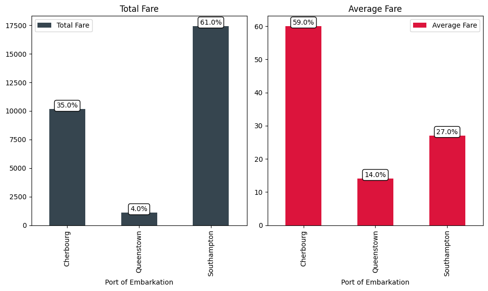

```python
fig, axes = plt.subplots(1,2, figsize=(10,6))
embarkation_dataframe.plot(kind='bar', subplots=True, color=colors, xlabel="Port of Embarkation", ax=axes)
addCaption(embarkation_dataframe, 'df', axes, None, ['Cherbourg', 'Queenstown', 'Southampton'])
plt.tight_layout()
plt.show()
```

- The Southampton (S) Port recorded the highest sum of ticket sales at $17,439.62, representing 61\% of the total, followed by the \ Cherbourg (C) Port at $10,152.24 (35%) with Queenstown (Q) Port recording the least sales overall of $1,102.23 (4%).
- The ticket seems to be more expensive at the Cherbourg Port at the average cost of $60, followed by the Southampton Port with \ average ticket cost of $27, while the average fare at Queenstown was $14

### #1b) Analysis of Trip Fare by Ticket Class

```python
fare_by_pclass = data.groupby('Pclass')['Fare'].sum()
passenger_by_pclass = data.groupby('Pclass')['Fare'].size()
avg_fare_by_pclass = data.groupby('Pclass')['Fare'].mean()

data_by_pclass = pd.DataFrame({'Total Fare': fare_by_pclass, 'Number of Passengers': passenger_by_pclass, \
                   'Average Fare': round(avg_fare_by_pclass, 2)})
data_by_pclass
```

| Pclass | Total Fare | Number of Passengers | Average Fare |
| --- | --- | --- | --- |
| 1 | 18177.40 | 216 | 84.15 |
| 2 | 3801.84 | 184 | 20.66 |
| 3 | 6714.85 | 491 | 13.68 |

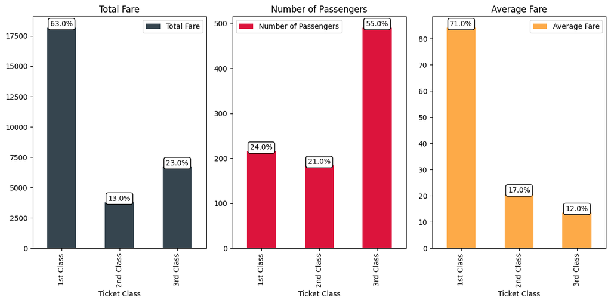

```python
fig, axes = plt.subplots(1,3, figsize=(12,6))
data_by_pclass.plot(kind='bar', subplots=True, color=colors, xlabel="Ticket Class", ax=axes)
addCaption(data_by_pclass, 'df', axes, None, ['1st Class', '2nd Class', '3rd Class'])
plt.tight_layout()
plt.show()
```

- The highest sales ($18,177.4 at 63%) was recorded with First Class ticket, followed by Third Class ticket with total sales of $6,714.85 at 23%  
  while the least sales was with the Second Class ticket at the sum of $3,801 at 13%.
- An average First Class ticket cost as high as $84, followed by Second Class ticket at $20.66 and Third Class ticket at $13.68
- A total of 216 passengers boarded the First Class ticket, while 184 passengers were recorded for Second Class with Third Class  
  having the highest number of passengers of 491.

### #1c) Analysis of Trip Fare by Age

```python
fare_by_sex = data.groupby('AgeGroup')['Fare'].sum()
passenger_by_sex = data.groupby('AgeGroup')['Fare'].size()
avg_fare_by_sex = data.groupby('AgeGroup')['Fare'].mean()

data_by_sex = pd.DataFrame({'Total Fare': round (fare_by_sex,2), 'Average Fare': round(avg_fare_by_sex, 2)})
data_by_sex
```

| AgeGroup | Total Fare | Average Fare |
| --- | --- | --- |
| Adult | 18801.75 | 33.51 |
| Child | 3693.10 | 31.30 |
| Senior | 317.96 | 28.91 |
| Young Adult | 5881.28 | 29.26 |

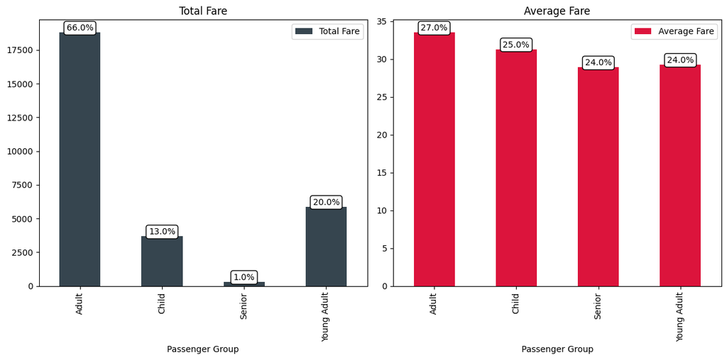

```python
fig, axes = plt.subplots(1,2, figsize=(12,6))
data_by_sex.plot(kind='bar', subplots=True, color=colors, xlabel="Passenger Group", ax=axes)
addCaption(data_by_sex, 'df', axes)
plt.tight_layout()
plt.show()
```

### #2a) Analysis of Passengers by Age and Gender

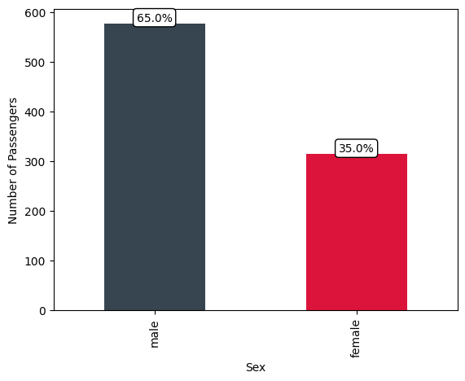

```python
ax = data['Sex'].value_counts().plot(kind="bar", ylabel='Number of Passengers', color=colors)
addCaption(data['Sex'].value_counts(), 'sr',  None, ax)
```

- The Titanic trip was dominated by male passengers, amounting to 65% of the total passengers, representing almost double the female numbers, while female passengers represent 35% of the passengers.

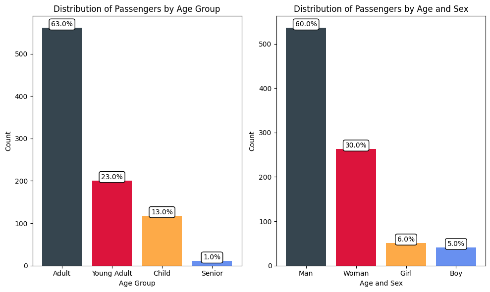

```python
age_group = data['AgeGroup'].value_counts()
gender_group = data['MWBG'].value_counts()

fig, ax = plt.subplots(1, 2, figsize=(10, 6))

ax[0].bar(age_group.index, age_group.values, color=colors)
ax[0].set_title('Distribution of Passengers by Age Group')
ax[0].set_xlabel('Age Group')
ax[0].set_ylabel('Count')
addCaption(age_group, 'sr',  None, ax[0])


ax[1].bar(gender_group.index, gender_group.values, color=colors)
ax[1].set_title('Distribution of Passengers by Age and Sex')
ax[1].set_xlabel('Age and Sex')
ax[1].set_ylabel('Count')
addCaption(gender_group, 'sr',  None, ax[1])

plt.tight_layout()
plt.show()
```

- The distribution by age group reveals that the Adult age group made largest number of the passengers at 63% of the overall passengers, followed by the Young Adults representing 23% of the passengers, children made 13% and Senior citizens were so few at 1%.
- The distribution by sex shows that men formed 60% of the total passengers, followed by women at 30%, boys made 5% of the passengers, while girls formed 6%.

### #2b) Analysis of Passengers by Port of Embarkation

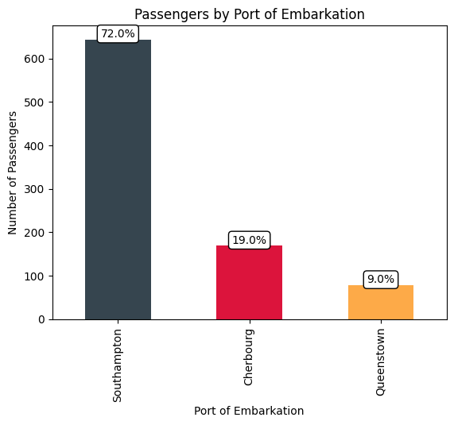

```python
survival_by_port = data['Embarked'].value_counts()
#survival_group = survival_by_port.rename(columns={0: 'Not Survived', 1: 'Survived'})
ax = survival_by_port.plot(kind="bar", title="Passengers by Port of Embarkation", xlabel='Port of Embarkation', \
                      ylabel='Number of Passengers', color=colors)
ax.set_xticklabels(['Southampton', 'Cherbourg', 'Queenstown'])
addCaption(survival_by_port, 'sr', None, ax, None)
```

- The Southampton Port recorded the largest number of passengers, 72% of the passengers boarded from this port, followed by the Cherbourg Port with 19% of the passengers with Queenstown recording the list number of passengers at 9%

### #2c) Analysis of Passengers by Cabin Group

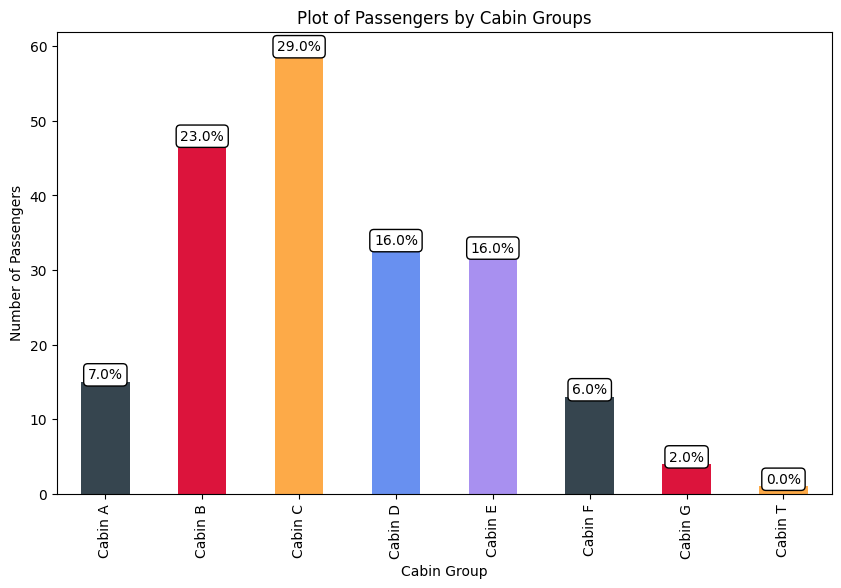

```python
# This is not good for analysis
# I added it just in case there was any dataset that has the Cabin column intact or...
# for any other purpose not mentioned.

cabin_counts = raw_data['Cabin'].value_counts()
first_letter = cabin_counts.index.str[0]

cabin_grp_counts = cabin_counts.groupby(first_letter).sum()

ax = cabin_grp_counts.plot(kind="bar", title="Plot of Passengers by Cabin Groups", figsize= (10, 6), color=colors, \
                      ylabel='Number of Passengers', xlabel='Cabin Group')
ax.set_xticklabels(['Cabin {}'.format(label.get_text()) for label in ax.get_xticklabels()])
addCaption(cabin_grp_counts, 'sr', None, ax)
```

- This analysis is based on the 204 Cabin numbers captured out of the 891 passengers in the dataset.
- Majority of the passengers occupied Cabin C in the ship, followed by Cabin B, Cabin D and E with equal number of passengers. The number of passengers shows 60 as its peak, this is due to over 70% of the Cabin information missing from the dataset.

### #2d) Analysis of Passengers by Travel Partner

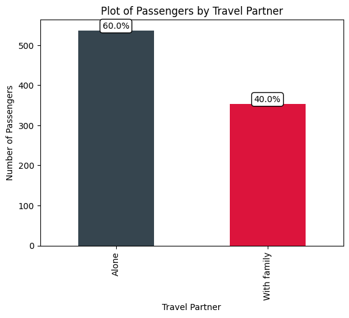

```python
ax = data['TravelPartner'].value_counts().plot(kind="bar", title='Plot of Passengers by Travel Partner', \
                                               xlabel='Travel Partner', ylabel='Number of Passengers', color=colors)
addCaption(data['TravelPartner'].value_counts(), 'sr', None, ax)
```

- The passengers were grouped into two classes, those who traveled alone, represnting 60%, while passengers who traveled with either parent and child or sibling and spouse represent the remaining 40%

### #3a) Analysis of Overall Survival rate

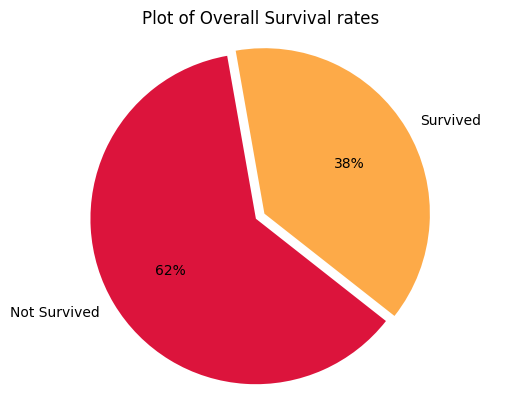

```python
survivor_group = data.groupby('Survived').size()
explode =(0, 0.06)
labels = ['Not Survived', 'Survived']
svplot = survivor_group.plot(kind="pie", explode=explode, autopct='%1.0f%%', labels=labels, startangle=100, \
                             title="Plot of Overall Survival rates", colors=[colors[1],colors[2]])
#svplot.set_xticklabels(['Not survived', 'Survived'])
plt.axis('equal')
addCaption(survivor_group, 'sr', None, svplot)
plt.show()
```

### #3b) Analysis of Survival rate by Genger

| Survived Sex | 0 | 1 |
| --- | --- | --- |
| female | 81 | 233 |
| male | 468 | 109 |

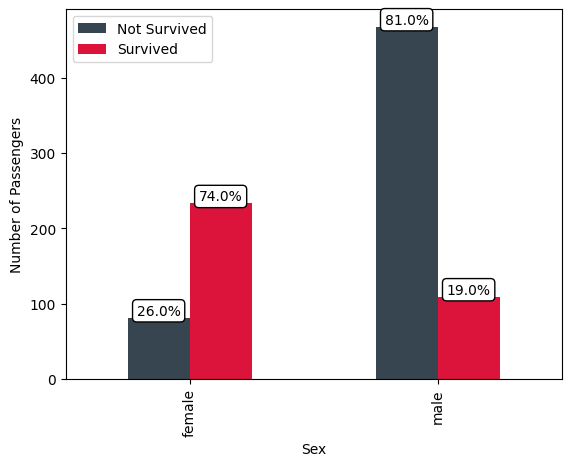

```python
survival_by_gender = data.groupby(['Sex','Survived']).size().unstack()
ax = survival_by_gender.plot(kind="bar", ylabel='Number of Passengers', color=colors)
ax.legend(['Not Survived', 'Survived'])
survival_by_gender
addCaption(survival_by_gender,'df', None, ax)
survival_by_gender
```

- The female gender had higher chances of survival, 74% of the female passengers, totalling 233 survived the Titanic wreck, while 19% of the male passengers, totalling 109 survived.
- 81% of the males and 26% of the females did not survive the Titanic.

### #3c) Analysis of Survival rate by Travel Partner

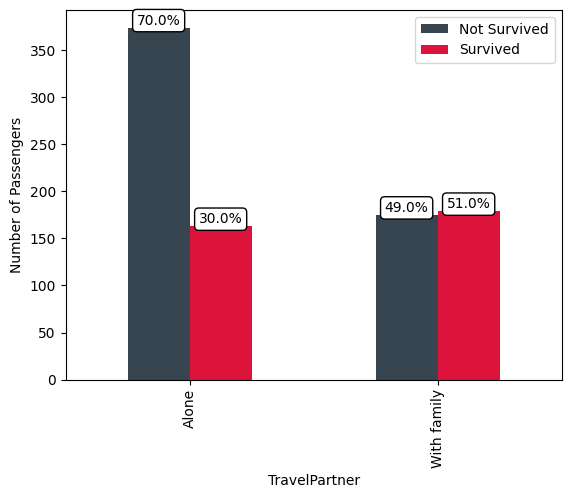

```python
survival_by_partner = data.groupby(['TravelPartner','Survived']).size().unstack()
ax = survival_by_partner.plot(kind="bar", ylabel='Number of Passengers', color=colors)
ax.legend(['Not Survived', 'Survived'])
survival_by_partner
addCaption(survival_by_partner,'df', None, ax)
```

- Most casualties of the shipwreck were passengers who traveled alone, the plot shows 70% of passengers traveling alone  
  did not survive the wreck, while 30% of those in this category survived.
- Out of the passengers traveling with one or more family members, 51% survived the accident, while 49% never survived.

### #3d) Analysis of Survival rate by Port of Embarkation

| Survived Embarked | Not Survived | Survived |
| --- | --- | --- |
| C | 75 | 94 |
| Q | 47 | 31 |
| S | 427 | 217 |

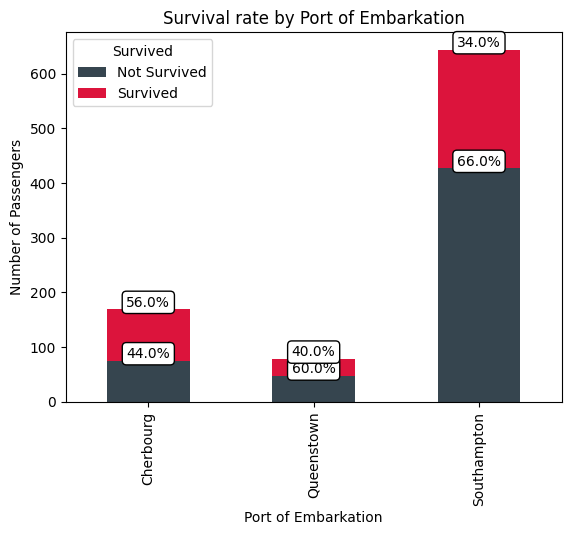

```python
survival_by_port = data.groupby([data['Embarked'],'Survived']).size().unstack()
survival_group = survival_by_port.rename(columns={0: 'Not Survived', 1: 'Survived'})
ax = survival_group.plot(kind="bar", title="Survival rate by Port of Embarkation", stacked=True,\
                    xlabel='Port of Embarkation',ylabel='Number of Passengers', color=colors)
ax.set_xticklabels(['Cherbourg', 'Queenstown', 'Southampton'])
addCaption(survival_by_port,'df', None, ax,)
survival_group
```

- Most of the casualties are passengers who boarded at the Southampton Port, this is proportional since the port also recorded the highest number of passengers on the ship.
- The Southampton Port recorded 217 at 34% of its passengers as survivors, while 427 at 66% of its passengers never survived.
- The Cherbourg Port recorded 94 at 56% of its passengers as survivors, while 75 at 44% of its passengers never survived.
- The Queenstown Port recorded 31 at 40% of its passengers as survivors, while 47 at 60% of its passengers never survived.

### #3e) Analysis of Survival rate by Cabin Group

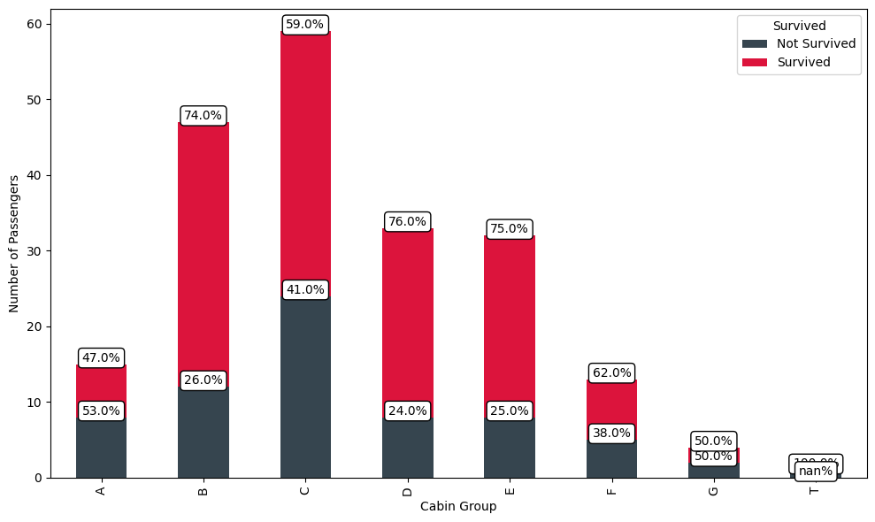

| Survived Cabin | Not Survived | Survived |
| --- | --- | --- |
| A | 8.0 | 7.0 |
| B | 12.0 | 35.0 |
| C | 24.0 | 35.0 |
| D | 8.0 | 25.0 |
| E | 8.0 | 24.0 |
| F | 5.0 | 8.0 |
| G | 2.0 | 2.0 |
| T | 1.0 | NaN |

```python
#fig, axes = plt.subplots(1,2, figsize=(10,6))
grouped_data = raw_data.groupby([raw_data['Cabin'].str[0], 'Survived']).size().unstack()
survival_by_cabin = grouped_data.rename(columns={0:'Not Survived', 1:'Survived'})

ax = survival_by_cabin.plot(kind="bar", figsize=(10, 6), stacked=True, color=colors, \
                       xlabel='Cabin Group', ylabel='Number of Passengers')
addCaption(survival_by_cabin, 'df',None, ax)
plt.tight_layout()
plt.show()

survival_by_cabin
```

- Out of the 204 Cabin numbers recorded, Cabins C has the highest number of surviving and non-surviving passengers. 35 (59%) passengers survived, while 24 (41%) were non-survivors.  
  NOTE: The figures above does not represent the true state of the survivors by Cabin, this is because the Cabin column has too many missing values, up to 77% of the entries.

### #3f) Analysis of Survival rate by Ticket Class

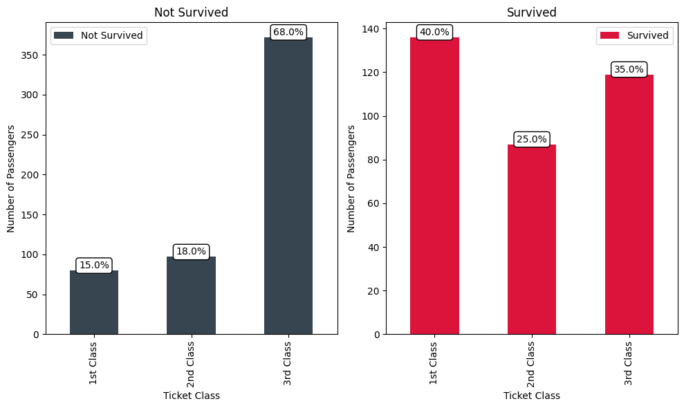

| Survived Pclass | Not Survived | Survived |
| --- | --- | --- |
| 1 | 80 | 136 |
| 2 | 97 | 87 |
| 3 | 372 | 119 |

```python
fig, axes = plt.subplots(1,2, figsize=(10,6))
grouped_ticket = data.groupby([data['Pclass'], 'Survived']).size().unstack()
survival_by_pclass = grouped_ticket.rename(columns={0:'Not Survived', 1:'Survived'})

survival_by_pclass.plot(kind="bar", subplots=True, color=colors, xlabel='Ticket Class', \
                        ylabel='Number of Passengers', ax=axes)
addCaption(survival_by_pclass, 'df', axes, None, ['1st Class', '2nd Class', '3rd Class'])
plt.tight_layout()
plt.show()

survival_by_pclass
```

### #3g) Analysis of Survival rate by Sex and Age

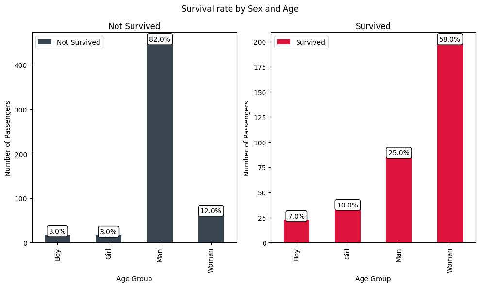

| Survived MWBG | Not Survived | Survived |
| --- | --- | --- |
| Boy | 18 | 23 |
| Girl | 17 | 34 |
| Man | 450 | 86 |
| Woman | 64 | 199 |

```python
fig, axes = plt.subplots(1,2, figsize=(10,6))
grouped_age = data.groupby([data['MWBG'], 'Survived']).size().unstack()
survival_by_age = grouped_age.rename(columns={0:'Not Survived', 1:'Survived'})

survival_by_age.plot(kind="bar", subplots=True, color=colors, xlabel='Age Group', \
                     title = 'Survival rate by Sex and Age', ylabel='Number of Passengers', ax=axes)
addCaption(survival_by_age, 'df', axes, None)
plt.tight_layout()
plt.show()

survival_by_age
```

- Women formed the most survivors of the Titanic shipwreck, forming 58% of the survivors, followed by men at 25% of the survivors, girls formed 10% and boys formed 7% of the overall survivors.
- Men formed the highest number of non-survivors, with a count of 450, a huge 82% of the non-survivors.

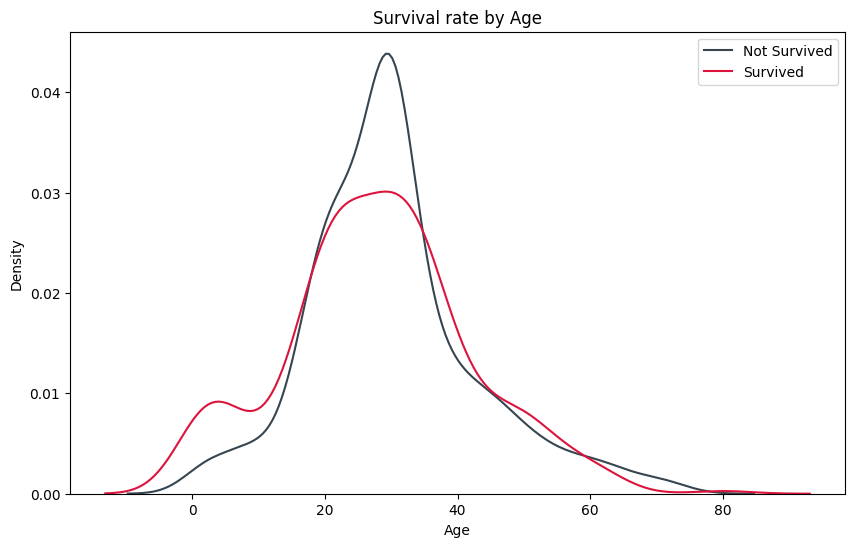

```python
plt.figure(figsize=(10, 6))
sns.kdeplot(data[data['Survived'] == 0]['Age'], label='Not Survived', color=colors[0])
sns.kdeplot(data[data['Survived'] == 1]['Age'], label='Survived', color=colors[1])

plt.title('Survival rate by Age')
plt.xlabel('Age')
plt.ylabel('Density')
plt.legend()
plt.show()
```